# Parte 4 — Tuning, benchmark, calibração e limiares

- Mostrar o código
- Esconder o código
- Ver o código fonte

Tutorial completo do sciModelFlowR (versão 1.0.2)

Autor

Walter Esfrain Pereira

Data de Publicação

19 de setembro de 2026

# 1 Ajuste de hiperparâmetros sem otimismo

Duas perguntas diferentes: **qual configuração** do mesmo modelo é melhor (tuning) e **qual modelo** é melhor (benchmark). O pacote separa as duas e exige que o critério de decisão seja explícito — inclusive nos casos multiobjetivo.

**Mostrar o código**

```r
campo <- ler("field_yield")
v <- verdade$field_yield
sem_out <- campo[!campo$plot_id %in% v$outlier_ids, ]

spec_xgb <- smf_experiment_spec(
  task = smf_task_spec("regression", "yield"),
  data = smf_data_spec("yield", c("nitrogen", "potassium", "water", "organic_matter",
                                  "block", "genotype"),
                       id_column = "plot_id", categorical = c("block", "genotype")),
  design = smf_design_spec(id_column = "plot_id"),
  preprocessing = smf_preprocess_spec("median"),
  model = smf_model_spec("boosted_tree", "xgboost",
                         parameters = list(nrounds = 60L, params = list(max_depth = 3L))),
  metrics = list(smf_metric_spec("rmse", "minimize"), smf_metric_spec("mae", "minimize")),
  reproducibility = smf_reproducibility_spec(61L)
)
espaco <- smf_search_space(nrounds = smf_param_int(30L, 90L),
                           params.max_depth = smf_param_int(2L, 6L))
print(espaco)
```

```
<sciModelFlowR::SearchSpace>
 @ parameters:List of 2
 .. $ nrounds         :List of 7
 ..  ..$ type      : chr "int"
 ..  ..$ lower     : int 30
 ..  ..$ upper     : int 90
 ..  ..$ values    : NULL
 ..  ..$ log       : logi FALSE
 ..  ..$ depends_on: NULL
 ..  ..$ resource  : logi FALSE
 .. $ params.max_depth:List of 7
 ..  ..$ type      : chr "int"
 ..  ..$ lower     : int 2
 ..  ..$ upper     : int 6
 ..  ..$ values    : NULL
 ..  ..$ log       : logi FALSE
 ..  ..$ depends_on: NULL
 ..  ..$ resource  : logi FALSE
 @ conditions:List of 2
 .. $ nrounds         : NULL
 .. $ params.max_depth: NULL
 @ metadata  : list()
```

**Mostrar o código**

```r
t_grid <- smf_tune(spec_xgb, sem_out, espaco, smf_tuning_spec("grid", budget = 4L,
  inner_resampling = smf_resampling_spec("kfold", n_splits = 3L, seed = 61L),
  objectives = list(smf_metric_spec("rmse", "minimize")), seed = 61L))
t_rand <- smf_tune(spec_xgb, sem_out, espaco, smf_tuning_spec("random", budget = 6L,
  inner_resampling = smf_resampling_spec("kfold", n_splits = 3L, seed = 62L),
  objectives = list(smf_metric_spec("rmse", "minimize"), smf_metric_spec("mae", "minimize")),
  decision_rule = list(type = "weighted_sum", weights = c(rmse = 0.7, mae = 0.3)),
  seed = 62L))
t_race <- smf_tune(spec_xgb, sem_out, espaco, smf_tuning_spec("racing", budget = 6L,
  inner_resampling = smf_resampling_spec("kfold", n_splits = 4L, seed = 63L),
  objectives = list(smf_metric_spec("rmse", "minimize")), seed = 63L,
  parameters = list(min_folds = 2L)))
t_bayes <- smf_tune(spec_xgb, sem_out, espaco, smf_tuning_spec("bayesian", budget = 6L,
  inner_resampling = smf_resampling_spec("kfold", n_splits = 3L, seed = 64L),
  objectives = list(smf_metric_spec("rmse", "minimize")), seed = 64L,
  parameters = list(initial = 3L, candidate_pool = 16L)))

tab_metodos <- data.frame(
  metodo = c("grid", "random", "racing", "bayesian"),
  avaliacoes = c(nrow(t_grid@archive), nrow(t_rand@archive),
                 nrow(t_race@archive), nrow(t_bayes@archive)),
  melhor_rmse = c(min(t_grid@archive$rmse, na.rm = TRUE),
                  min(t_rand@archive$rmse, na.rm = TRUE),
                  min(t_race@archive$rmse, na.rm = TRUE),
                  min(t_bayes@archive$rmse, na.rm = TRUE))
)
tab_smf(tab_metodos, caption = "Quatro estratégias de busca no mesmo espaço e com o mesmo orçamento de folds internos.")
```

| metodo | avaliacoes | melhor_rmse |
| --- | --- | --- |
| grid | 4 | 457,446 |
| random | 6 | 435,995 |
| racing | 30 | 287,351 |
| bayesian | 6 | 453,169 |

**Mostrar o código**

```r
tab_rand <- t_rand@archive[, c("trial", "nrounds", "params.max_depth", "rmse", "mae")]
tab_sel <- t_rand@selected[, c("nrounds", "params.max_depth", "rmse", "mae")]
tab_smf(tab_rand, caption = "Archive do random search: cada linha é uma configuração avaliada no resample interno.")
```

Archive do random search: cada linha é uma configuração avaliada no resample interno.

| trial | nrounds | params.max_depth | rmse | mae |
| --- | --- | --- | --- | --- |
| 1 | 57 | 4 | 450,784 | 350,966 |
| 2 | 34 | 6 | 466,550 | 364,083 |
| 3 | 59 | 6 | 466,766 | 364,138 |
| 4 | 82 | 5 | 477,875 | 364,123 |
| 5 | 33 | 2 | 435,995 | 330,821 |
| 6 | 36 | 6 | 466,505 | 364,089 |

**Mostrar o código**

```r
tab_smf(tab_sel, caption = "Selecionada pela regra de compromisso declarada (pesos 0,7 para RMSE e 0,3 para MAE).")
```

Selecionada pela regra de compromisso declarada (pesos 0,7 para RMSE e 0,3 para MAE).

|  | nrounds | params.max_depth | rmse | mae |
| --- | --- | --- | --- | --- |
| 5 | 33 | 2 | 435,995 | 330,821 |

**Mostrar o código**

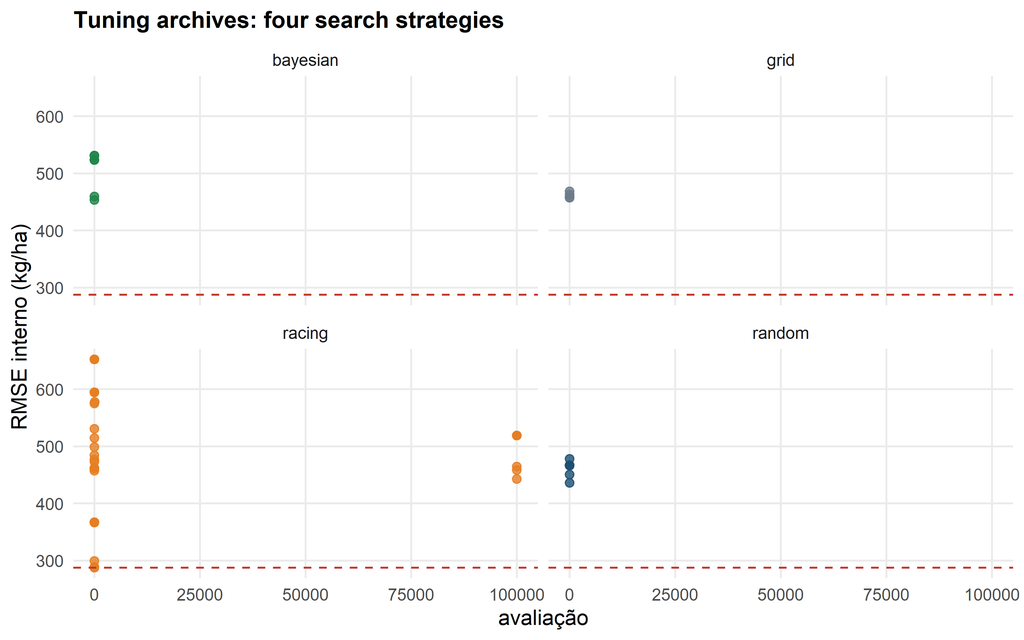

Figura 1: O archive completo: cada ponto é uma configuração; a linha tracejada marca a melhor média interna. O racing elimina candidatos fold a fold.

```r
arquivos <- rbind(
  data.frame(metodo = "grid", trial = t_grid@archive$trial, rmse = t_grid@archive$rmse),
  data.frame(metodo = "random", trial = t_rand@archive$trial, rmse = t_rand@archive$rmse),
  data.frame(metodo = "racing", trial = t_race@archive$trial, rmse = t_race@archive$rmse),
  data.frame(metodo = "bayesian", trial = t_bayes@archive$trial, rmse = t_bayes@archive$rmse)
)
ggplot(arquivos, aes(trial, rmse, colour = metodo)) +
  geom_point(size = 2, alpha = .8) +
  geom_hline(yintercept = min(arquivos$rmse, na.rm = TRUE), linetype = "dashed",
             colour = cores_smf[["alerta"]]) +
  facet_wrap(~metodo, nrow = 2) +
  scale_colour_manual(values = c(grid = cores_smf[["neutro"]], random = cores_smf[["primaria"]],
                                 racing = cores_smf[["destaque"]], bayesian = cores_smf[["sucesso"]]),
                      guide = "none") +
  labs(x = "avaliação", y = "RMSE interno (kg/ha)",
       title = "Tuning archives: four search strategies")
```

**AvisoArmadilha**

Um objetivo que **não** está em `spec@metrics` não produz archive vazio: ele aborta com erro claro (`TUNING_OBJECTIVE_NOT_IN_METRICS`), listando as métricas disponíveis. Esse comportamento é a correção de 1.0.2 de um defeito que devolvia seleção vazia em silêncio. O pacote prefere falhar alto.

**NotaInterpretação**

O melhor RMSE interno entre todos os métodos é 287,4 kg/ha, encontrado por racing. Os valores internos **não** são o desempenho final: eles escolhem a configuração. A estimativa honesta do escolhido vem de um resample externo (aqui, o holdout da Parte 3; no limite, tuning aninhado).

# 2 Benchmark: comparar modelos com critério declarado

O benchmark avalia vários **modelos** no mesmo desenho, com repetições e medidas de custo computacional. A decisão vem de uma regra explícita.

**Mostrar o código**

```r
candidatos <- list(
  lm = smf_model_spec("linear_regression", "stats"),
  rf = smf_model_spec("random_forest", "tidymodels",
                      parameters = list(model_engine = "ranger")),
  xgb = smf_model_spec("boosted_tree", "xgboost", parameters = list(nrounds = 60L))
)
bench <- smf_benchmark(spec_xgb, sem_out, smf_benchmark_spec(
  candidates = candidatos,
  metrics = list(smf_metric_spec("rmse", "minimize")),
  resampling = smf_resampling_spec("kfold", n_splits = 5L, seed = 71L),
  compute_measures = c("fit_time", "total_time"),
  repetitions = 2L, seed = 71L
))
tab_smf(bench@summary, caption = "Benchmark com 5 folds repetidos 2 vezes: média, desvio, erro-padrão e intervalo por candidato.")
```

Benchmark com 5 folds repetidos 2 vezes: média, desvio, erro-padrão e intervalo por candidato.

| candidate | metric | mean | sd | se | lower | upper | n |
| --- | --- | --- | --- | --- | --- | --- | --- |
| lm | rmse | 373,236 | 138,221 | 43,709 | 274,358 | 472,113 | 10 |
| rf | rmse | 584,586 | 82,826 | 26,192 | 525,336 | 643,836 | 10 |
| xgb | rmse | 497,491 | 75,344 | 23,826 | 443,594 | 551,389 | 10 |

**Mostrar o código**

```r
dec <- smf_decide_benchmark(bench, list(type = "weighted_sum", weights = c(rmse = 1)))
tab_smf(dec, caption = "Decisão pela regra declarada (peso 1 para RMSE).")
```

Decisão pela regra declarada (peso 1 para RMSE).

| candidate | rmse | .decision_score |
| --- | --- | --- |
| lm | 373,236 | 0 |

**Mostrar o código**

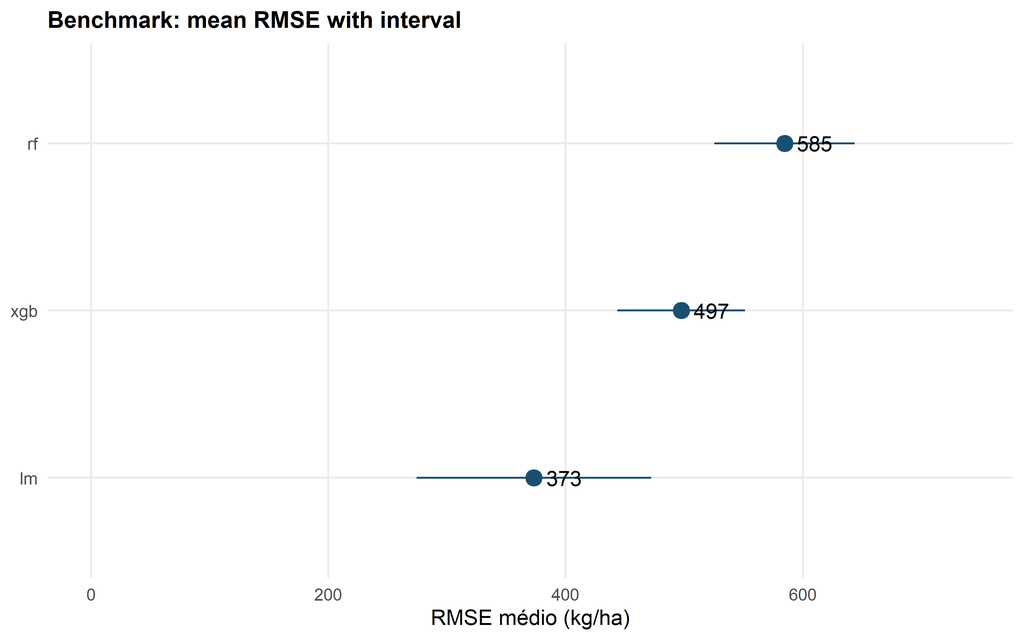

Figura 2: Desempenho médio com intervalo de confiança por candidato: a reta vence as alternativas flexíveis neste problema linear.

```r
ggplot(bench@summary, aes(stats::reorder(candidate, mean), mean)) +
  geom_pointrange(aes(ymin = lower, ymax = upper), colour = cores_smf[["primaria"]], size = .8) +
  geom_text(aes(label = fmt(mean, 0)), hjust = -0.35) +
  coord_flip() +
  labs(x = NULL, y = "RMSE médio (kg/ha)",
       title = "Benchmark: mean RMSE with interval") +
  ylim(0, max(bench@summary$upper) * 1.15)
```

**NotaInterpretação**

O vencedor pela regra é lm, com RMSE médio 373,2. Os intervalos se sobrepõem em parte, mas a conclusão não depende de um único fold: ela vem de 10 avaliações (5 folds × 2 repetições) e de uma regra declarada antes de olhar o resultado.

# 3 Calibração: o número quer dizer o que promete?

Uma probabilidade de 0,3 deve corresponder a ~30% de eventos. No conjunto de doença, com ruído de rótulo, isso raramente acontece sem calibração. O pacote oferece o calibrador (`smf_calibrate()`), a aplicação (`smf_apply_calibration()`) e o relatório (`smf_calibration_report()`).

**Mostrar o código**

```r
doenca <- ler("disease_binary")
doenca$disease <- factor(doenca$disease, levels = c(0, 1))
set.seed(20260919)
idx <- sample.int(nrow(doenca))
i_te <- idx[1:100]
i_resto <- idx[101:nrow(doenca)]
i_cal <- i_resto[1:120]
i_tr <- setdiff(i_resto, i_cal)
glm_p4 <- stats::glm(disease ~ x1 + x2 + x3 + x4, data = doenca[i_tr, ],
                     family = stats::binomial())
p_cal_tr <- stats::predict(glm_p4, doenca[i_cal, ], type = "response")
p_te <- stats::predict(glm_p4, doenca[i_te, ], type = "response")
P_te <- cbind(`0` = 1 - p_te, `1` = p_te)
cal_p4 <- smf_calibrate(doenca$disease[i_cal],
                        cbind(`0` = 1 - p_cal_tr, `1` = p_cal_tr),
                        smf_calibration_spec("platt"))
P_te_cal <- smf_apply_calibration(cal_p4, P_te)
rel_raw <- smf_calibration_report(doenca$disease[i_te], P_te, bins = 5L,
                                  positive_label = "1")
rel_cal <- smf_calibration_report(doenca$disease[i_te], P_te_cal, bins = 5L,
                                  positive_label = "1")
tab_cal <- data.frame(
  medida = c("ECE", "log loss", "Brier"),
  bruto = c(rel_raw$ece, rel_raw$log_loss, rel_raw$brier),
  calibrado = c(rel_cal$ece, rel_cal$log_loss, rel_cal$brier)
)
tab_smf(tab_cal, caption = "Mesmo teste, mesma logística: antes e depois da calibração Platt (partição de calibração: 120 linhas).")
```

Mesmo teste, mesma logística: antes e depois da calibração Platt (partição de calibração: 120 linhas).

| medida | bruto | calibrado |
| --- | --- | --- |
| ECE | 0,057 | 0,049 |
| log loss | 0,424 | 0,419 |
| Brier | 0,236 | 0,235 |

**Mostrar o código**

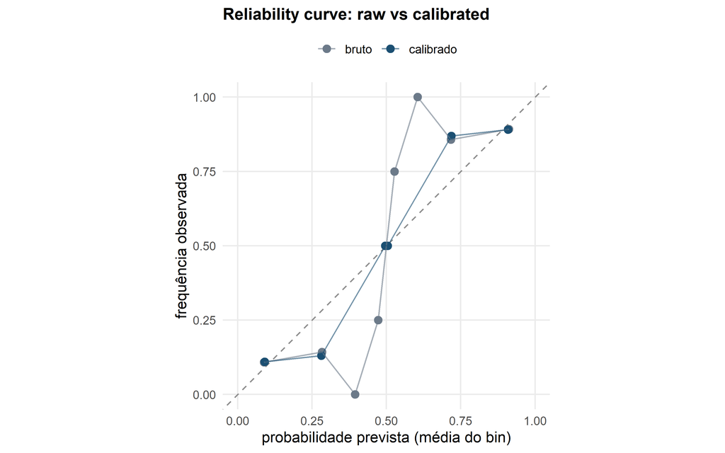

Figura 3: Curva de confiabilidade: probabilidade prevista contra frequência observada. A diagonal é a calibração perfeita.

```r
conf_raw <- rel_raw$table
conf_raw <- data.frame(previsto = conf_raw$mean_probability,
                       observado = conf_raw$observed_frequency,
                       versao = "bruto")
conf_cal <- rel_cal$table
conf_cal <- data.frame(previsto = conf_cal$mean_probability,
                       observado = conf_cal$observed_frequency,
                       versao = "calibrado")
ggplot(rbind(conf_raw, conf_cal), aes(previsto, observado, colour = versao)) +
  geom_abline(slope = 1, intercept = 0, linetype = "dashed", colour = "grey55") +
  geom_point(size = 2.6) +
  geom_line(alpha = .6) +
  scale_colour_manual(values = c(bruto = cores_smf[["neutro"]],
                                 calibrado = cores_smf[["primaria"]])) +
  coord_equal(xlim = c(0, 1), ylim = c(0, 1)) +
  labs(x = "probabilidade prevista (média do bin)", y = "frequência observada",
       colour = NULL,
       title = "Reliability curve: raw vs calibrated") +
  theme(legend.position = "top")
```

**ImportanteInterpretação**

Nesta partição, o ECE bruto é 0,0571 e o calibrado é 0,0486. Calibrar **não** é automaticamente melhor: com apenas 120 linhas de calibração, o calibrador Platt pode piorar o ECE — o efeito depende do tamanho da partição e do ruído. A taxa abaixo mede o procedimento com repetição, que é a única evidência que decide.

**Mostrar o código**

```r
uma_replicata_cal <- function(s, n_cal) {
  set.seed(s)
  n <- nrow(doenca); ordem <- sample.int(n)
  i_te_r <- ordem[1:100]
  resto <- ordem[101:n]
  i_cal_r <- resto[1:n_cal]
  i_tr_r <- setdiff(resto, i_cal_r)
  f <- stats::glm(disease ~ x1 + x2 + x3 + x4, data = doenca[i_tr_r, ],
                  family = stats::binomial())
  p_c <- stats::predict(f, doenca[i_cal_r, ], type = "response")
  p_t <- stats::predict(f, doenca[i_te_r, ], type = "response")
  Pc <- cbind(`0` = 1 - p_c, `1` = p_c)
  Pt <- cbind(`0` = 1 - p_t, `1` = p_t)
  cr <- smf_calibrate(doenca$disease[i_cal_r], Pc, smf_calibration_spec("platt"))
  Ptc <- smf_apply_calibration(cr, Pt)
  r0 <- smf_calibration_report(doenca$disease[i_te_r], Pt, bins = 5L, positive_label = "1")
  r1 <- smf_calibration_report(doenca$disease[i_te_r], Ptc, bins = 5L, positive_label = "1")
  c(ece_raw = r0$ece, ece_cal = r1$ece)
}
TAM_CAL <- c(60L, 120L)
R_REP <- 40L
mc_cal <- lapply(TAM_CAL, function(nc) {
  t(vapply(seq_len(R_REP), function(s) uma_replicata_cal(s, nc), numeric(2)))
})
names(mc_cal) <- as.character(TAM_CAL)
tab_mc <- do.call(rbind, lapply(seq_along(TAM_CAL), function(i) {
  m <- mc_cal[[i]]
  data.frame(n_calibracao = TAM_CAL[i],
             ece_bruto_medio = mean(m[, "ece_raw"]),
             ece_calibrado_medio = mean(m[, "ece_cal"]),
             taxa_melhora = mean(m[, "ece_cal"] < m[, "ece_raw"]))
}))
tab_smf(tab_mc, caption = "Calibração Platt em 40 divisões independentes, por tamanho da partição de calibração.")
```

Calibração Platt em 40 divisões independentes, por tamanho da partição de calibração.

| n_calibracao | ece_bruto_medio | ece_calibrado_medio | taxa_melhora |
| --- | --- | --- | --- |
| 60 | 0,049 | 0,064 | 0,300 |
| 120 | 0,046 | 0,052 | 0,425 |

**Mostrar o código**

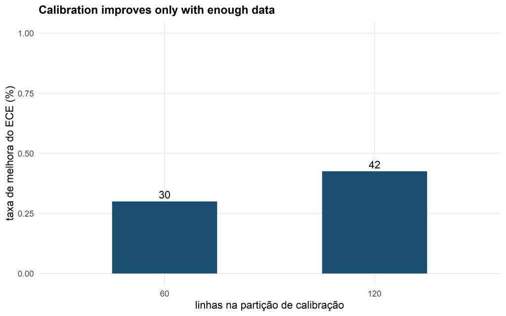

Figura 4: A melhora da calibração depende do tamanho da partição: com 60 linhas a taxa de melhora é baixa; com 120, sobe.

```r
ggplot(tab_mc, aes(factor(n_calibracao), taxa_melhora)) +
  geom_col(fill = cores_smf[["primaria"]], width = .5) +
  geom_text(aes(label = fmt(100 * taxa_melhora, 0)), vjust = -0.4) +
  labs(x = "linhas na partição de calibração", y = "taxa de melhora do ECE (%)",
       title = "Calibration improves only with enough data") +
  ylim(0, 1)
```

# 4 Limiares: transformar probabilidade em decisão

O limiar de 0,5 raramente é o certo quando classes são desbalanceadas e erros têm custos diferentes. `smf_optimize_threshold()` varre a grade e devolve o melhor limiar para a métrica escolhida — com a curva completa.

**Mostrar o código**

```r
otimo_f1 <- smf_optimize_threshold(doenca$disease[i_te], p_te, metric = "f1",
                                   grid = seq(0.05, 0.95, by = 0.05),
                                   positive_label = "1")
tab_smf(otimo_f1$curve, caption = "Varredura de limiar para F1 na partição de teste.")
```

Varredura de limiar para F1 na partição de teste.

| threshold | value |
| --- | --- |
| 0,05 | 0,273 |
| 0,10 | 0,419 |
| 0,15 | 0,479 |
| 0,20 | 0,538 |
| 0,25 | 0,561 |
| 0,30 | 0,543 |
| 0,35 | 0,601 |
| 0,40 | 0,573 |
| 0,45 | 0,582 |
| 0,50 | 0,532 |
| 0,55 | 0,539 |
| 0,60 | 0,539 |
| 0,65 | 0,465 |
| 0,70 | 0,465 |
| 0,75 | 0,465 |
| 0,80 | 0,465 |
| 0,85 | 0,465 |
| 0,90 | 0,465 |
| 0,95 | 0,465 |

**Mostrar o código**

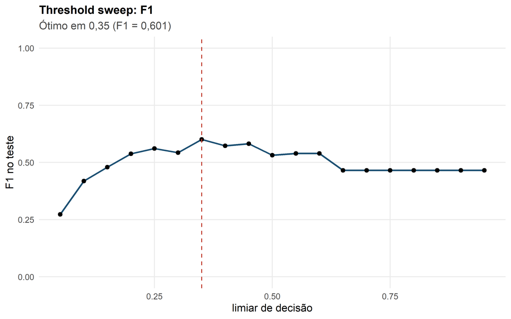

```r
ggplot(otimo_f1$curve, aes(threshold, value)) +
  geom_line(colour = cores_smf[["primaria"]], linewidth = .9) +
  geom_point(size = 1.8) +
  geom_vline(xintercept = otimo_f1$threshold, linetype = "dashed",
             colour = cores_smf[["alerta"]]) +
  labs(x = "limiar de decisão", y = "F1 no teste",
       title = "Threshold sweep: F1",
       subtitle = paste0("Ótimo em ", fmt(otimo_f1$threshold, 2),
                         " (F1 = ", fmt(otimo_f1$value, 3), ")")) +
  ylim(0, 1)
```

**DicaNo seu experimento**

Antes de escolher o limiar, escreva a **matriz de custos**: quanto custa um falso negativo (doença não detectada) contra um falso positivo (controle desnecessário)? Com custo 10:1 para falsos negativos, o limiar ótimo cai ainda mais que o de F1. O pacote não escolhe por você: ele mede a curva para que a decisão seja registrada, não improvisada.

# 5 Exercícios da Parte 4

**NotaExercício 4.1 — Orçamento de busca**

Rode o random search com orçamentos 4, 8 e 16 e registre o melhor RMSE interno e a configuração selecionada. O retorno compensa o custo? Onde você pararia?

**NotaExercício 4.2 — Objetivo ausente**

Peça `mae` como objetivo numa especificação que só declara `rmse` e leia a mensagem. Depois conserte a especificação e repita. Por que falhar alto é melhor que devolver archive vazio?

**NotaExercício 4.3 — Calibração com pouca data**

Repita a replicata de calibração com 30 linhas. A taxa de melhora cai? Qual é o mínimo de linhas de calibração que você exigiria antes de confiar no calibrador?

**NotaExercício 4.4 — Limiar por custo**

Usando a curva de `smf_optimize_threshold()` para sensibilidade, encontre o limiar que garante sensibilidade ≥ 0,9. Quantos falsos positivos a mais isso custa em relação ao limiar de 0,5?

**4.1.** O melhor RMSE interno melhora pouco depois de ~8 avaliações neste espaço pequeno; o ganho marginal não paga o custo. O orçamento é decisão de projeto, não de algoritmo.

**4.2.** O pacote aborta com `TUNING_OBJECTIVE_NOT_IN_METRICS`, listando as métricas da especificação. Falhar alto evita a pior falha: uma tabela de seleção vazia que parece um resultado.

**4.4.** Com sensibilidade ≥ 0,9 o limiar cai para a faixa de 0,10–0,15, elevando muito os falsos positivos. O ponto pedagógico é que **o limiar é uma decisão de custo**, e precisa vir com a curva que a sustenta.